# Introduction to ggplot: course code

### 3.3.14 Let’s try adding the minimal theme

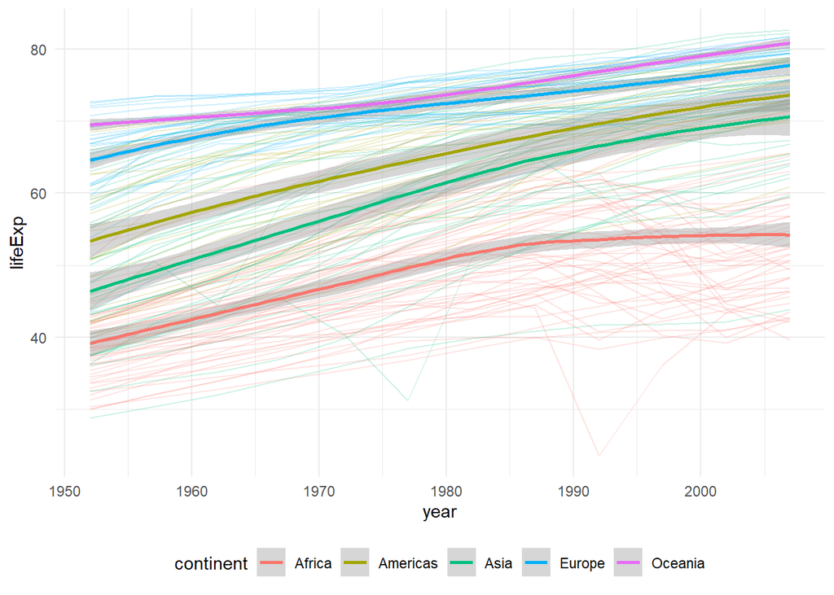

```r
ggplot(gapminder,
  aes(x = year,
      y = lifeExp,
      color = continent)) +
  geom_line(
    aes(group = country),
    alpha = 0.2) +
  geom_smooth() +
  theme_minimal() + #<<
  theme(
  legend.position = "bottom")
```

Fonts are kind of big

### 3.3.15 Can we make the font smaller?

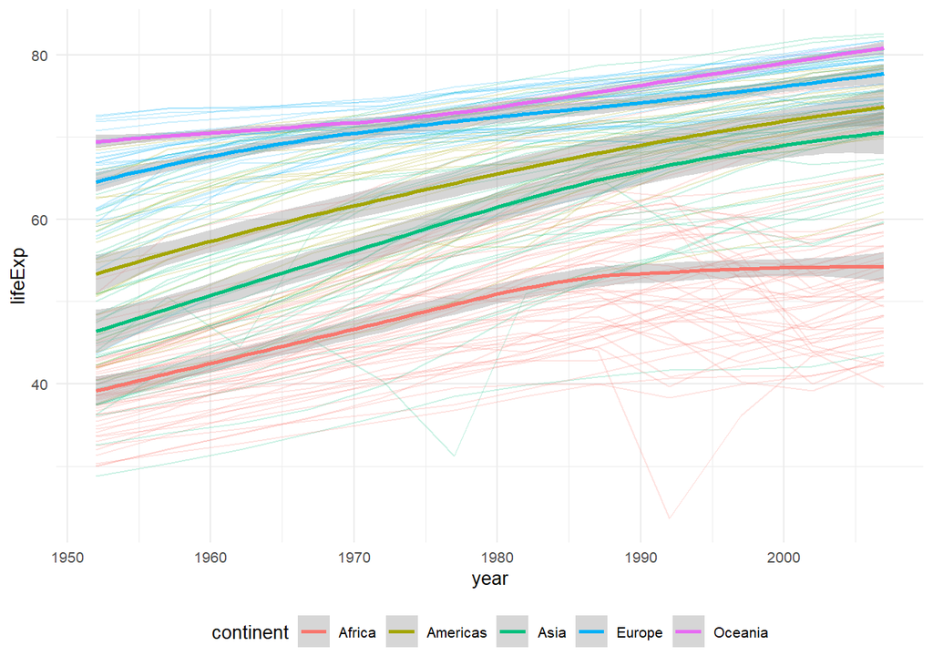

```r
ggplot(gapminder,
  aes(x = year,
      y = lifeExp,
      color = continent)) +
  geom_line(
    aes(group = country),
    alpha = 0.2) +
  geom_smooth() +
  theme_minimal(
    base_size = 10) + #<<
  theme(
  legend.position = "bottom")
```

Great, let’s switch gears

### 3.3.16 Let’s explore a few countries in more detail

```r
americas <-
  gapminder %>%
  filter(
    country %in% c(
      "Brazil",
      "Canada",
      "Mexico",
      "Ecuador"
    )
  )
```

### 3.3.17 Let’s look at four countries in more detail. How do their populations compare to each other?

```
## # A tibble: 10 x 6
##    country continent  year lifeExp       pop gdpPercap
##    <fct>   <fct>     <int>   <dbl>     <int>     <dbl>
##  1 Brazil  Americas   1952    50.9  56602560     2109.
##  2 Brazil  Americas   1957    53.3  65551171     2487.
##  3 Brazil  Americas   1962    55.7  76039390     3337.
##  4 Brazil  Americas   1967    57.6  88049823     3430.
##  5 Brazil  Americas   1972    59.5 100840058     4986.
##  6 Brazil  Americas   1977    61.5 114313951     6660.
##  7 Brazil  Americas   1982    63.3 128962939     7031.
##  8 Brazil  Americas   1987    65.2 142938076     7807.
##  9 Brazil  Americas   1992    67.1 155975974     6950.
## 10 Brazil  Americas   1997    69.4 168546719     7958.
```

### 3.3.18 Making a bar chart

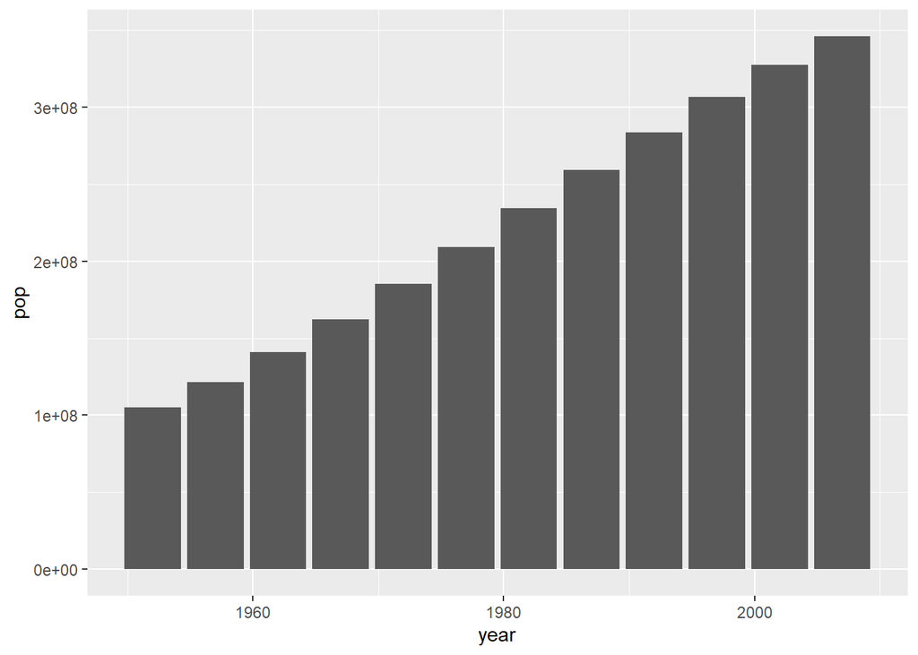

```r
ggplot(americas,
  aes(x = year,
      y = pop)
  ) +
  geom_col()
```

Yeah, but how many people are in each country?

### 3.3.19 Color the bars by country

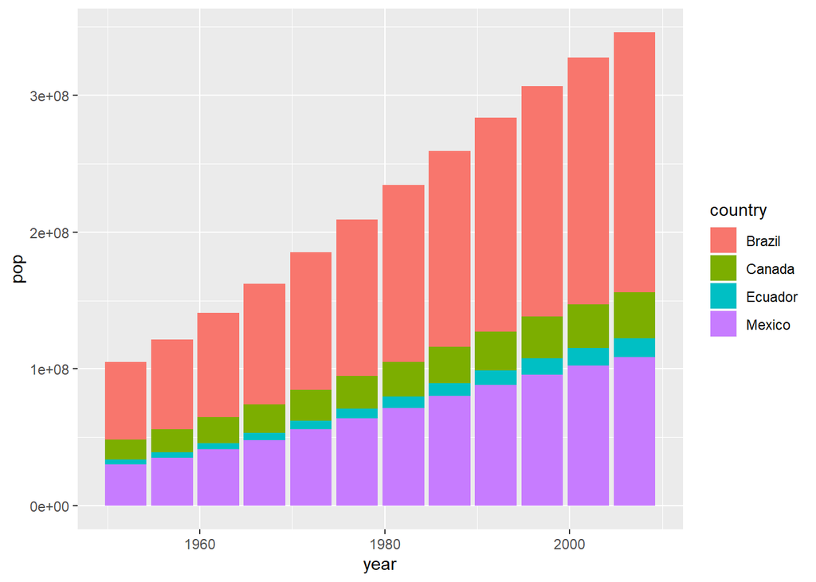

```r
ggplot(americas,
  aes(x = year,
      y = pop,
      fill = country) #<<
  ) +
  geom_col()
```

Can we reorder by population size?

### 3.3.20 Using fct_reorder() from the forcats package

Excellent tutorial by Jenny Bryan [“Be the Boss of your factors”](https://stat545.com/factors-boss.html)

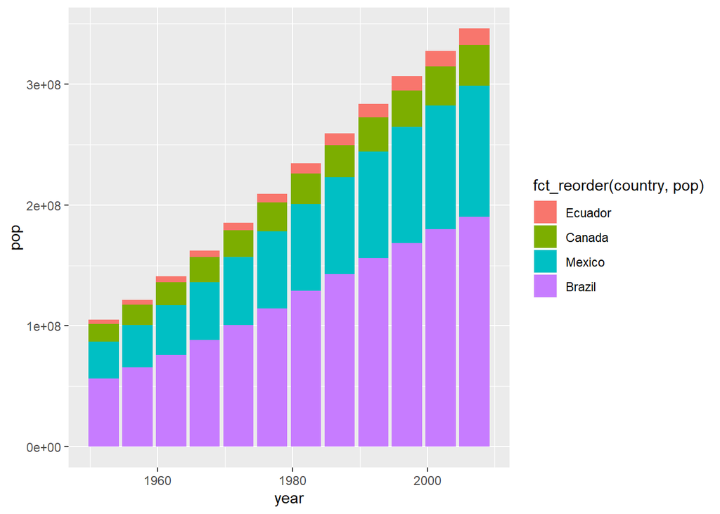

```r
ggplot(americas,
  aes(x = year,
      y = pop,
      fill = fct_reorder( #<<
        country, pop) #<<
      )
  ) +
  geom_col()
```

Can we change the labels?

### 3.3.21 Add a label for country.

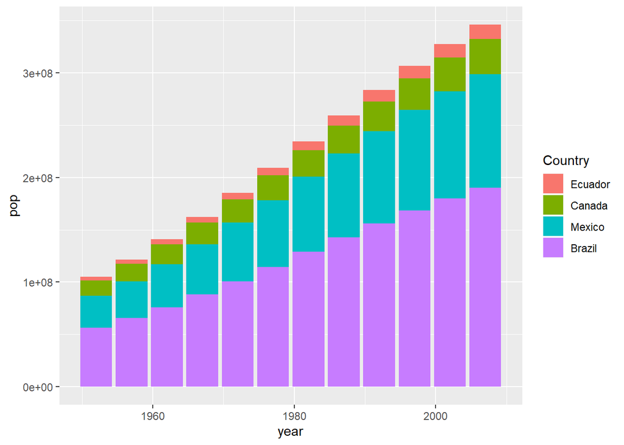

```r
ggplot(americas,
  aes(x = year,
      y = pop,
      fill = fct_reorder( #<<
        country, pop) #<<
      )
  ) +
  geom_col() +
  labs(fill = "Country") #<<
```

Bars are “stacked”, can we separate?

### 3.3.22 Changing the position using “dodge”

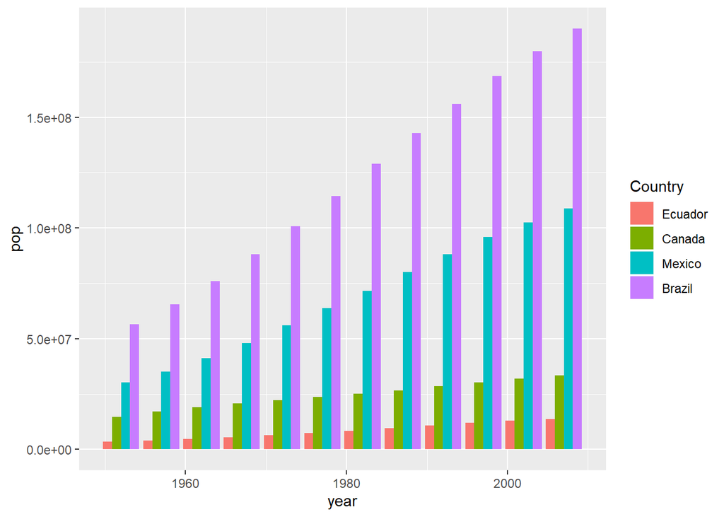

```r
ggplot(americas,
  aes(x = year,
      y = pop,
      fill = fct_reorder(
        country, pop)
      )
  ) +
  geom_col(
    position = "dodge") + #<<
  labs(fill = "Country")
```

`position = "dodge"` places objects *next to each other* instead of overlapping

What is scientific notation anyway?

### 3.3.23 Dividing population to be smaller

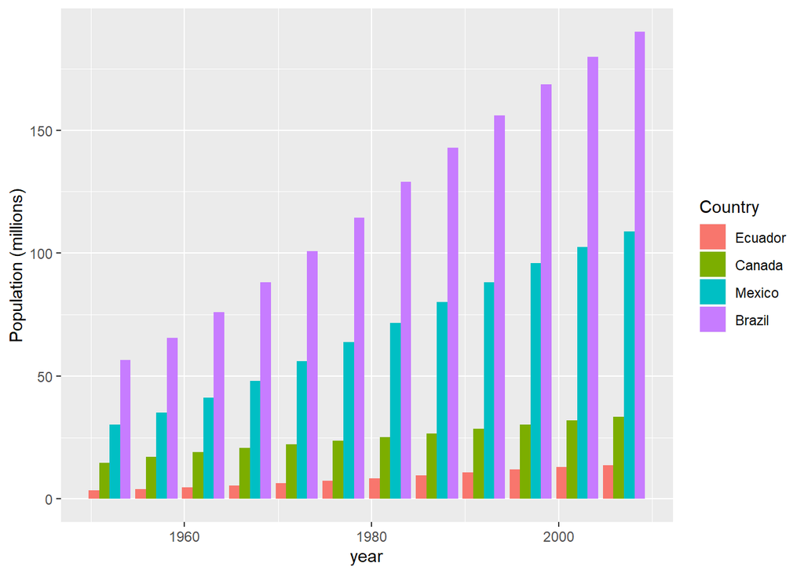

```r
ggplot(americas,
  aes(x = year,
      y = pop / 10^6, #<<
      fill = fct_reorder(
        country, pop)
      )
  ) +
  geom_col(
    position = "dodge"
  ) +
  labs(fill = "Country",
       y = "Population (millions)"#<<
       )
```

ggplot aesthetics can take expressions! Still, it might be easier to see countries individually

### 3.3.24 Using facet_wrap() to create individual plots

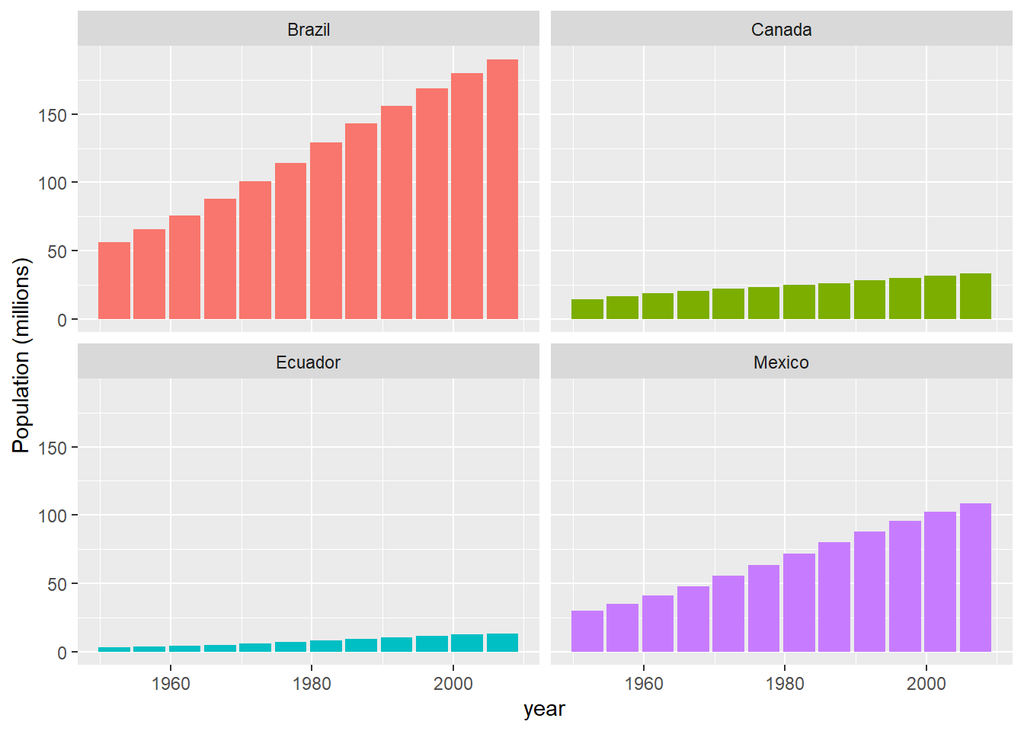

```r
ggplot(americas,
  aes(x = year,
      y = pop / 10^6, #<<
      fill = country) #<<
  ) +
  geom_col(
    position = "dodge"
  ) +
  labs(y = "Population (millions)") +
  facet_wrap(~ country) + #<<
  guides(fill = FALSE) #<<
```

Let range of y-axis vary in each plot

### 3.3.25 Changing the scales

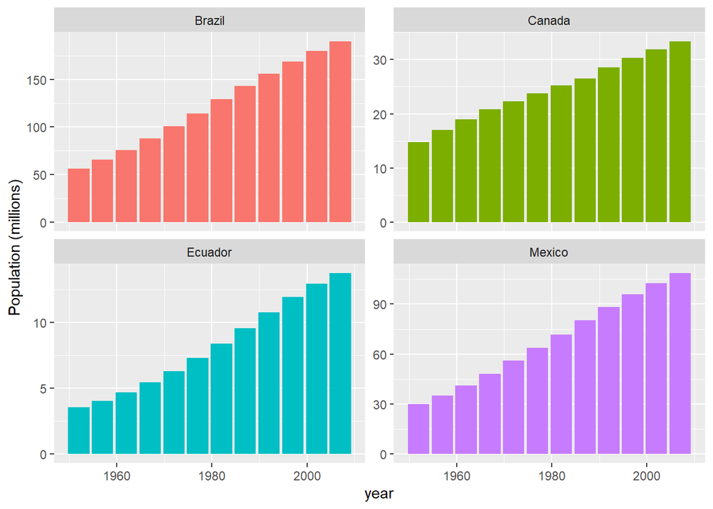

```r
ggplot(americas,
  aes(x = year,
      y = pop / 10^6,
      fill = country)
  ) +
  geom_col(
    position = "dodge"
  ) +
  labs(y = "Population (millions)") +
  facet_wrap(~ country,
    scales = "free_y") + #<<
  guides(fill = FALSE)
```

What about life expectancy again?

### 3.3.26 Making a barchart with life expectancy

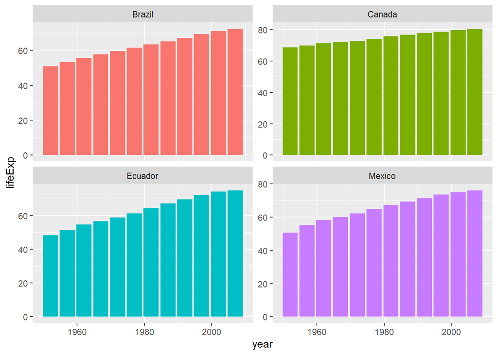

```r
ggplot(americas,
  aes(x = year,
      y = lifeExp, #<<
      fill = country)
  ) +
  geom_col(
    position = "dodge"
  ) +
  facet_wrap(~ country,
             scales = "free_y") +
  guides(fill = FALSE)
```

This should really be a line instead of a bar

### 3.3.27 Changing the plot to a line plot

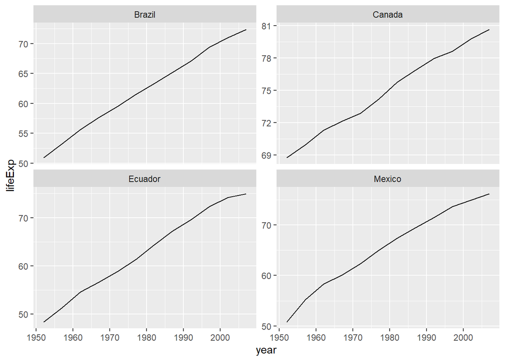

```r
ggplot(americas,
  aes(x = year,
      y = lifeExp,
      fill = country)
  ) +
  geom_line() + #<<
  facet_wrap(~ country,
             scales = "free_y") +
  guides(fill = FALSE)
```

### 3.3.28 Coloring each line by country. No need to show in the legend as each country has it’s own plot.

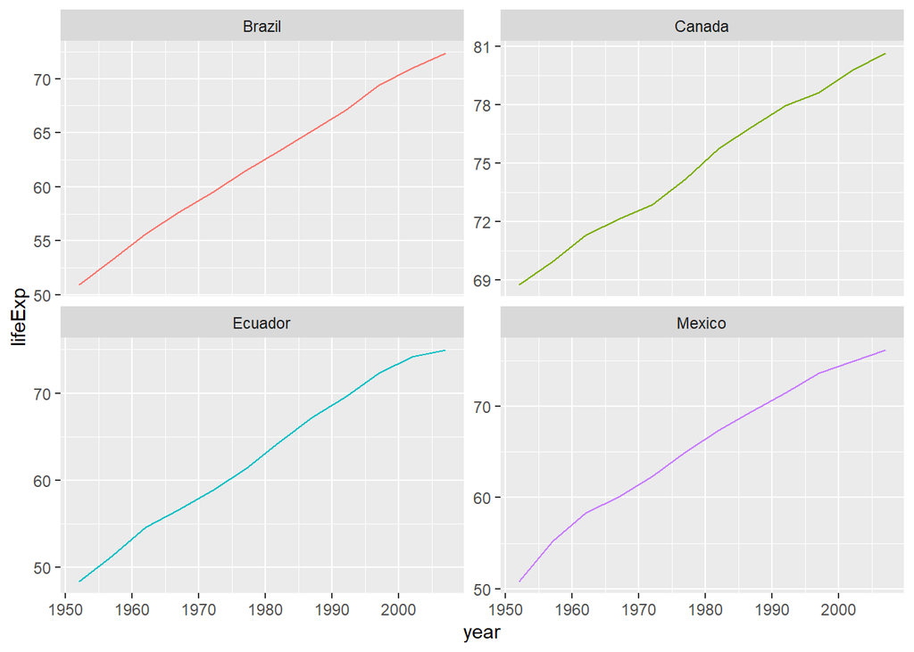

```r
ggplot(americas) +
  aes(
    x = year,
    y = lifeExp,
    color = country #<<
  ) +
  geom_line() +
  facet_wrap(~ country,
    scales = "free_y") +
  guides(color = FALSE) #<<
```

Altogether now!

### 3.3.29 Putting all the plots back together again

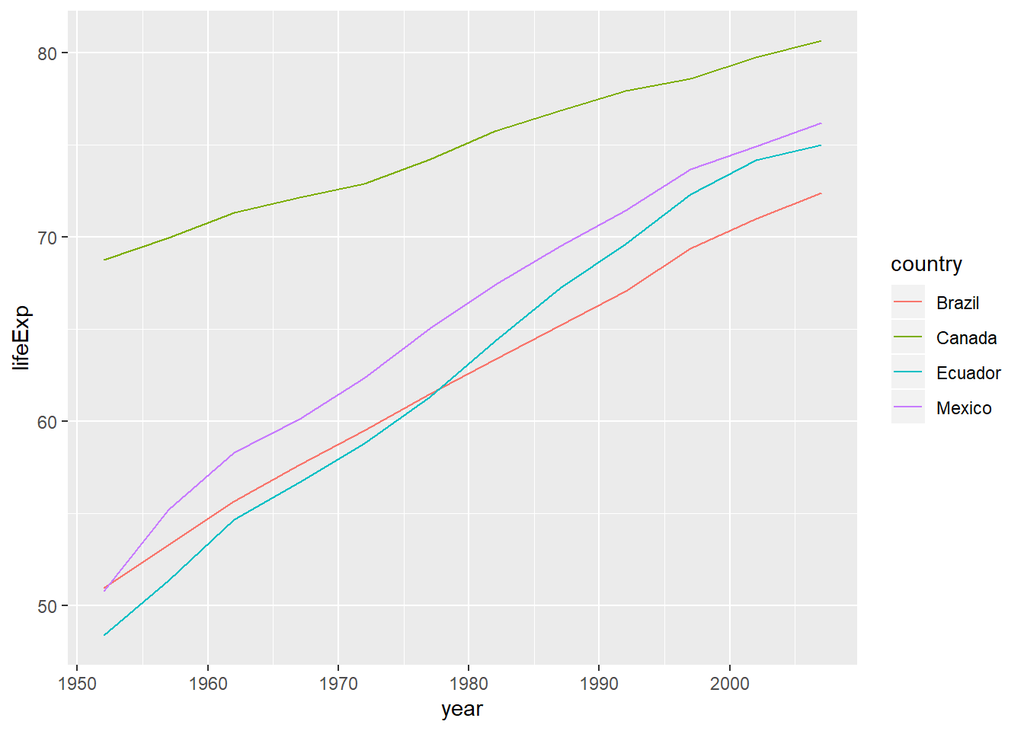

```r
ggplot(americas) +
  aes(
    x = year,
    y = lifeExp,
    color = country
  ) +
  geom_line()
```

Let’s update the labels

### 3.3.30 Adding labels to the plots

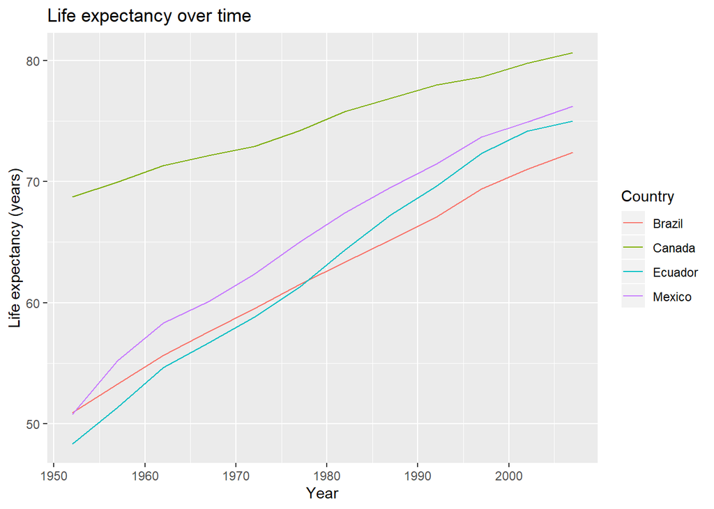

```r
ggplot(americas,
  aes(x = year,
      y = lifeExp,
      color = country)
  ) +
  geom_line() +
  labs(x = "Year",
       y = "Life expectancy (years)",
       color = "Country",
       title = "Life expectancy over time")
```

Okay, changing gears again. What is range of life expectancy in Americas?

### 3.3.31 Combining dplyr and ggplot code!

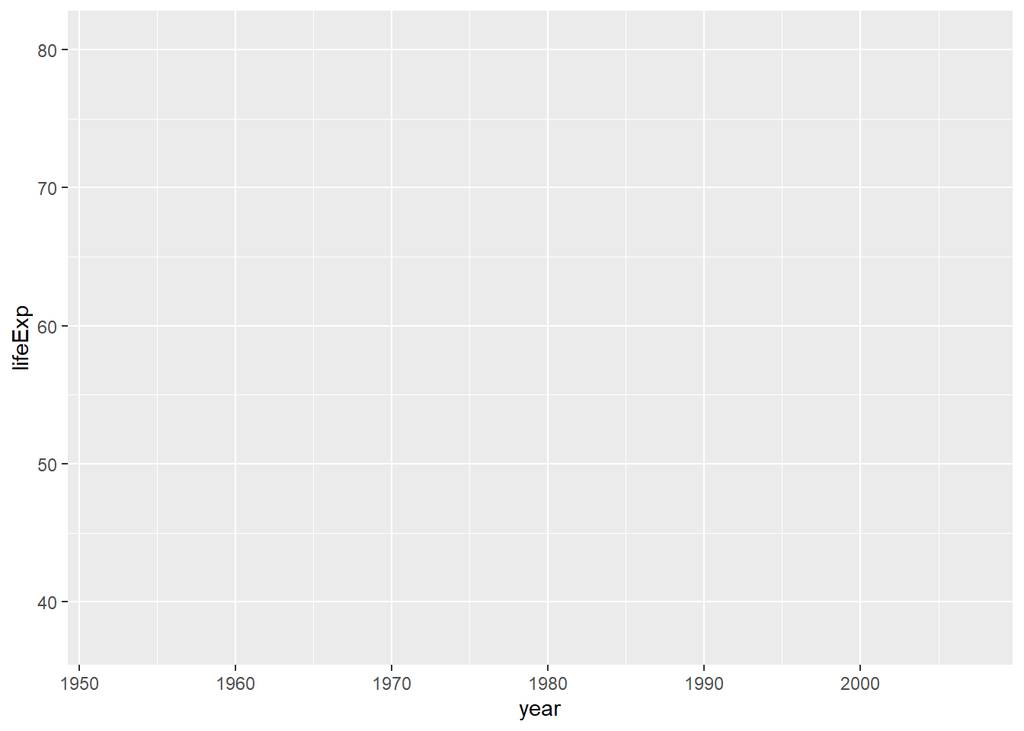

```r
gapminder %>%
  filter(
    continent == "Americas"
  ) %>% #<<
  ggplot( #<<
    aes(x = year,
        y = lifeExp)
  )
```

You can pipe into `ggplot()`!  
Just watch for `%>%` changing to `+`

## 3.4 Creating a box plot

Boxplot for life expectancy range

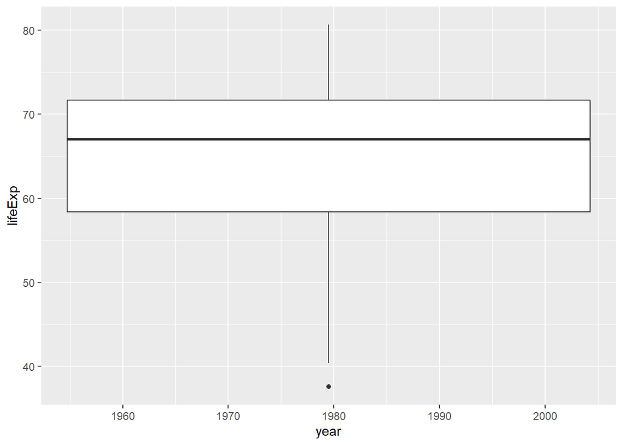

```r
gapminder %>%
  filter(
    continent == "Americas"
  ) %>%
  ggplot(
    aes(x = year,
        y = lifeExp)
  ) +
  geom_boxplot() #<<
```

Why not boxplots by year?

### 3.4.1 Creating the box plots by year

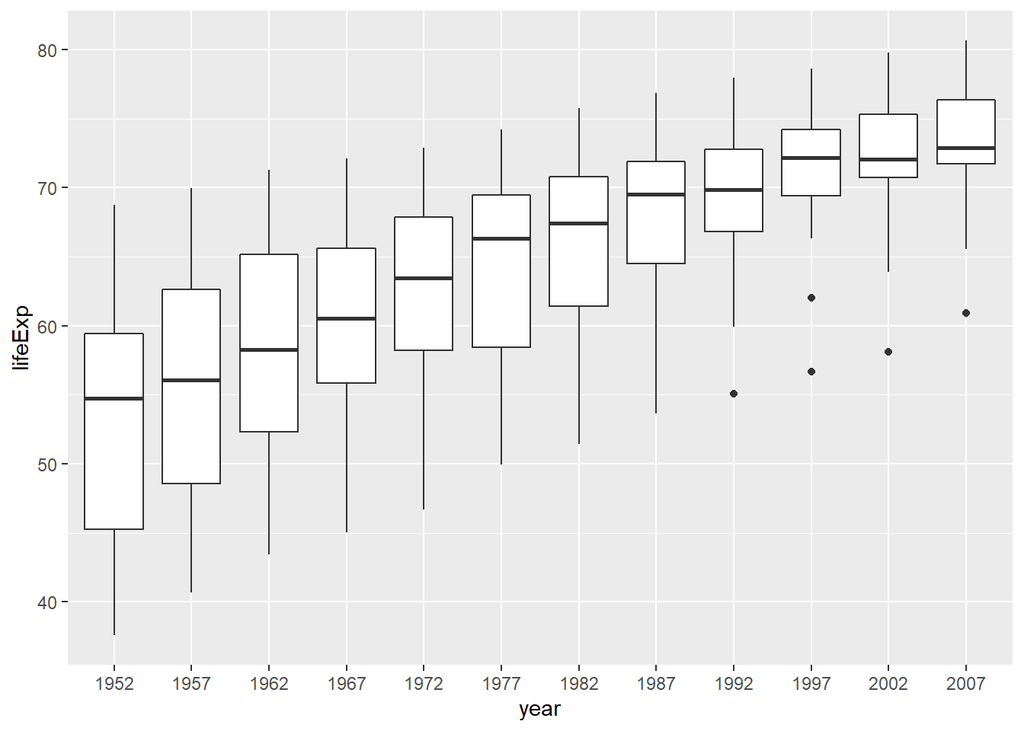

```r
gapminder %>%
  filter(
    continent == "Americas"
  ) %>%
  mutate( #<<
    year = factor(year) #<<
  ) %>%  #<<
  ggplot(
    aes(x = year,
        y = lifeExp)
  ) +
  geom_boxplot()
```

### 3.4.2 Changing the coordinates using coord_flip()

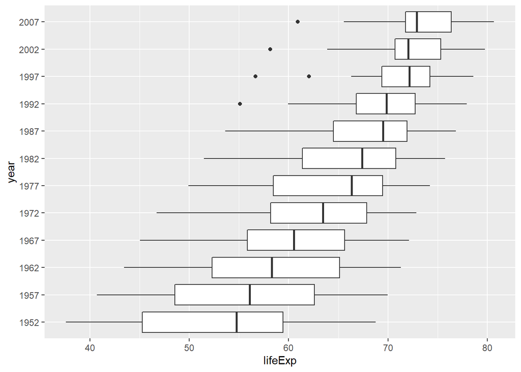

```r
gapminder %>%
  filter(
    continent == "Americas"
  ) %>%
  mutate(
    year = factor(year)
  ) %>%
  ggplot(
    aes(x = year,
        y = lifeExp)
  ) +
  geom_boxplot() +
  coord_flip() #<<
```